# DATA 308: Homework 3

Simple linear regression

Author

Dylan Wikel

*Please change the author name to your own. Answer in complete sentences.*

# Bike share data

We have data on bike ridership among registered members of the Capital Bikeshare service in Washington, D.C. rentals by weather.

## Question 0

Begin by running the code chunk below to load the `tidyverse` package and the `bikes` data from the `bayesrules` package. You may need to first install the packages using `install.packages(c("tidyverse", "bayesrules"))` in the Console.

```r
library(tidyverse)
library(bayesrules)

data("bikes")
```

## Question 1

Type ?bikes into the Console to view the data documentation. What is the description of the variables called `rides` and `temp_actual`?

### Response

`rides` refers to the number of bikeshare rides and `temp_actual` refers to raw temperature measured in degrees Fahrenheit.

## Question 2

We want to explore if we can use the temperature to predict the number of daily bikeshare rides we will get. Produce a plot to visualize the relationship between `rides` and `temp_actual`. Make sure to provide axes labels instead of just using the default labels. (Hint: Look at slide 10 of lecture 4a.)

### Response

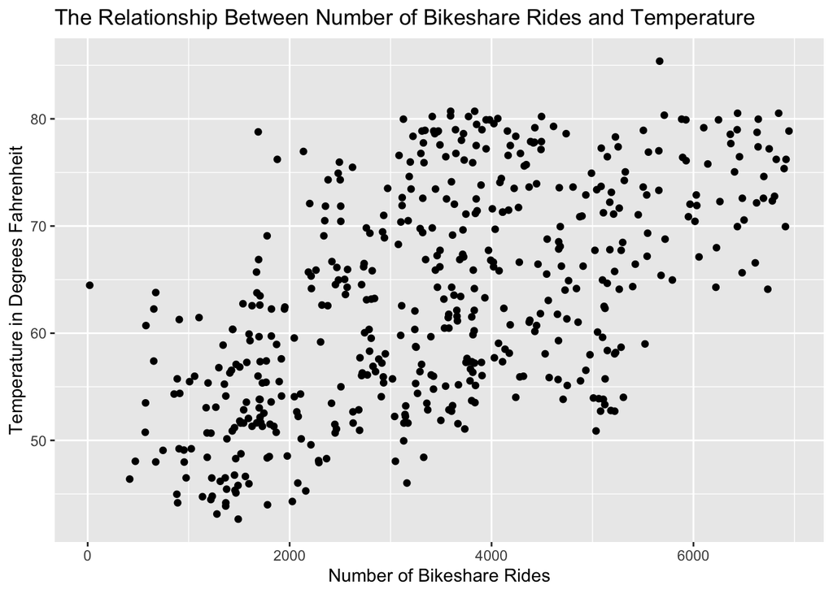

```r
ggplot(bikes,
       aes(x = rides,
           y = temp_actual)
       ) +
  geom_point() +
  labs(
    x = "Number of Bikeshare Rides",
    y = "Temperature in Degrees Fahrenheit",
    title = "The Relationship Between Number of Bikeshare Rides and Temperature"
  )
```

## Question 3

Reproduce your plot from question 2, but now add a linear regression line to the plot. Does it appear to model your data well?

### Response

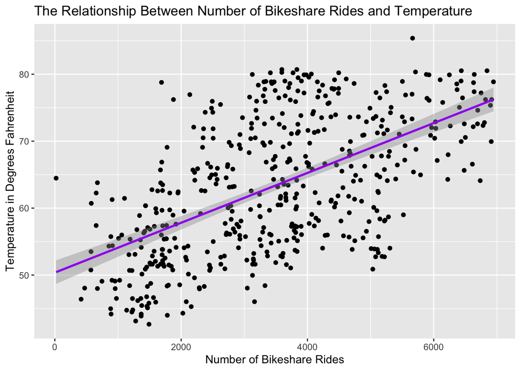

```r
ggplot(bikes,
       aes(x = rides,
           y = temp_actual)
       ) +
  geom_point() +
  geom_smooth(method = lm,
              color = "purple"
              ) +
  labs(
    x = "Number of Bikeshare Rides",
    y = "Temperature in Degrees Fahrenheit",
    title = "The Relationship Between Number of Bikeshare Rides and Temperature"
  )
```

The regression line models the data fairly well. I can see that there is a positive relationship between `temp_actual` and `rides` such that as `temp_actual` increases, `rides` also increases.

## Question 4

Fit a linear model to regress `rides` on `temp_actual`, saving your model as `bike_model`. Note, I did not provide a code chunk for you to use for this question. You will have to click the “+C” button at the top of this document to add an R code chunk.

### Response

```r
bike_model <- lm(rides ~ temp_actual, data = bikes)

summary(bike_model)
```

```
Call:
lm(formula = rides ~ temp_actual, data = bikes)

Residuals:
    Min      1Q  Median      3Q     Max
-3564.3 -1009.3  -116.4   959.1  3184.6

Coefficients:
            Estimate Std. Error t value Pr(>|t|)
(Intercept) -2168.77     363.64  -5.964 4.67e-09 ***
temp_actual    89.23       5.67  15.739  < 2e-16 ***
---
Signif. codes:  0 '***' 0.001 '**' 0.01 '*' 0.05 '.' 0.1 ' ' 1

Residual standard error: 1288 on 498 degrees of freedom
Multiple R-squared:  0.3322,    Adjusted R-squared:  0.3308
F-statistic: 247.7 on 1 and 498 DF,  p-value: < 2.2e-16
```

## Question 5

Specify the fitted model in context.

### Response

$$\hat Y{Rides_i} = -2168.77 + 89.23(Temperature_i)$$

## Question 6

Interpret the estimate for the y-intercept in context. Does it have a meaningful interpretation in this context?

### Response

The expected number of `ride` when `temp_actual` is equal to 0 is -2168.77 `ride`. This does not have meaningful interpretation in context as there are no recorded values in `temp_actual` equal to 0 and we would not expect a negative number of rides as it is impossible.

## Question 7

Interpret the estimate for the slope in context.

### Response

The slope in this context is 89.23. For each unit increase in `temp_actual`, we expect an increase in `ride` by 89.23.

## Question 8

Identify the 95% confidence interval for the slope and its corresponding margin of error.

### Response

```r
ci_bike <- confint(bike_model)["temp_actual", ]

# margin of error
bike_me <- (ci_bike[2] - ci_bike[1]) / 2

ci_bike
```

```
   2.5 %   97.5 %
 78.0944 100.3734
```

```r
bike_me
```

```
  97.5 %
11.13949
```

## Question 9

Improve your interpretation from question 7 here by adding the margin of error and confidence level into your interpretation.

### Response

A 1 degree increase in `temp_actual` is associated with an increase in bikeshare `ride`s of 89.23 plus or minus 11.13949 rides with 95% confidence.

## Question 10

What daily number of rides would our model predict for a day where the temperature is 70 degrees Fahrenheit?

### Response

```r
temp_data <- data.frame(temp_actual = 70)

predict(bike_model, newdata = temp_data, interval = "confidence")
```

```
       fit      lwr      upr
1 4077.598 3942.193 4213.004
```

```r
predict(bike_model, newdata = temp_data, interval = "prediction")
```

```
       fit      lwr      upr
1 4077.598 1543.132 6612.065
```

## Question 11

Identify the 95% interval for your prediction in question 10 and its corresponding margin of error.

### Response

For a 70 degree day, we expect 4077.598 bikeshare rides, between 3942.193 and 4213.004 rides, with 95% confidence.

## Question 12

Provide an interpretation of your prediction and interval from questions 10 and 11 in context, including your margin of error and confidence level into your interpretation.

### Response

For a 70 degree day, we predict 4077.598 bikeshare rides, between 1543.132 and 6612.065 rides, with 95% confidence.

## Question 13

What is the average daily number of rides would our model predict for days where the temperature is 70 degrees Fahrenheit?

### Response

## Question 14

Identify the 95% interval for your prediction in question 13 and its corresponding margin of error.

### Response

## Question 15

Provide an interpretation of your prediction and interval from questions 13 and 14 in context, including your margin of error and confidence level into your interpretation.

### Response

## Question 16

What daily number of rides would our model predict for a day where the temperature is 20 degrees Fahrenheit?

### Response

## Question 17

What is extrapolation and why is it dangerous?

### Response

# Homework Help

Have you done the homework by yourself, with a peer(s), or used tools like ChatGPT?

- If you provided help to a peer(s) and/or got help from your peers(s) please explain briefly what this entailed.
- If you used tools like ChatGPT, include the prompts you used and explain how the tool helped supported your learning.

## Response